# Prediction Assignment (Weight Lifting Exercises Dataset)

Harshada Sasturkar

14/08/2020

### Summary:

In this assignment the “Weight Lifting Exercises Dataset” has been used. It contains data from accelerometers on the belt, forearm, arm, and dumbell of 6 participants. They were asked to perform barbell lifts correctly and incorrectly in 5 different fashions. The classes(variable ‘classe’) represent each fashion. More information and the dataset can be obtained from (http://web.archive.org/web/20161224072740/http:/groupware.les.inf.puc-rio.br/har)

### Loading data:

```r
library(ggplot2)
library(iterators)
library(foreach)
library(parallel)
library(doParallel)
library(caret)
download.file("https://d396qusza40orc.cloudfront.net/predmachlearn/pml-training.csv",destfile = "pml-training.csv")
download.file("https://d396qusza40orc.cloudfront.net/predmachlearn/pml-testing.csv",destfile = "pml-testing.csv")
```

### Preparing data :

1. partitioning: First, the complete training dataset is partitioned into training and validation datasets. 3/4th data is used for training and remaining 1/4th will be used for validation. The testing dataset will be used at the end for prediction purpose.

```r
pmltrain<-read.csv("pml-training.csv")
pmltest<-read.csv("pml-testing.csv")
set.seed(1234)
intrain<-createDataPartition(pmltrain$classe,p=0.75)[[1]]
pmltrain1<-pmltrain[intrain,]
pmlval<-pmltrain[-intrain,]
```

2. Features selection: The dataset consists of some features which contain statistical summary values Ex. min_,max_,avg_,stddev_,etc. which have alot of missing values. Also features like X,problem_id and user_name don’t affect the outcome classe hence I’ve not considered such features.

```r
c<-grep("kurtosis|skewness|max|min|amplitude|var|avg|stddev",colnames(pmltrain))
pmltrain2<-pmltrain1[,-c(c,1,2)]
pmlval1<-pmlval[,-c(c,1,2)]
pmltest1<-pmltest[,-c(c,1,2,160)]
```

### Model building:

I have used random forest for training along with k-fold(in this case 5 fold) cross validation to increase overall accuracy.

```r
cluster <- makeCluster(detectCores() - 1)
registerDoParallel(cluster)
fitControl <- trainControl(method = "cv",number = 5,allowParallel = TRUE)
modpml<-train(classe~.,method="rf",data=pmltrain2,trControl = fitControl,verbose=FALSE)
```

*Note: For faster building, I’ve used parallel processing.*

### Testing(Validating):

1. The model is first tested on the training data itself to see the in-sample error.

```r
predtrain<-predict(modpml,newdata = pmltrain2)
confusionMatrix(predtrain,as.factor(pmltrain2$classe))
```

```
## Confusion Matrix and Statistics
##
##           Reference
## Prediction    A    B    C    D    E
##          A 4185    0    0    0    0
##          B    0 2848    0    0    0
##          C    0    0 2567    0    0
##          D    0    0    0 2412    0
##          E    0    0    0    0 2706
##
## Overall Statistics
##
##                Accuracy : 1
##                  95% CI : (0.9997, 1)
##     No Information Rate : 0.2843
##     P-Value [Acc > NIR] : < 2.2e-16
##
##                   Kappa : 1
##
##  Mcnemar's Test P-Value : NA
##
## Statistics by Class:
##
##                      Class: A Class: B Class: C Class: D Class: E
## Sensitivity            1.0000   1.0000   1.0000   1.0000   1.0000
## Specificity            1.0000   1.0000   1.0000   1.0000   1.0000
## Pos Pred Value         1.0000   1.0000   1.0000   1.0000   1.0000
## Neg Pred Value         1.0000   1.0000   1.0000   1.0000   1.0000
## Prevalence             0.2843   0.1935   0.1744   0.1639   0.1839
## Detection Rate         0.2843   0.1935   0.1744   0.1639   0.1839
## Detection Prevalence   0.2843   0.1935   0.1744   0.1639   0.1839
## Balanced Accuracy      1.0000   1.0000   1.0000   1.0000   1.0000
```

Since accuracy is 100% the in-sample error rate is 0%. This can also be seen in following plot:

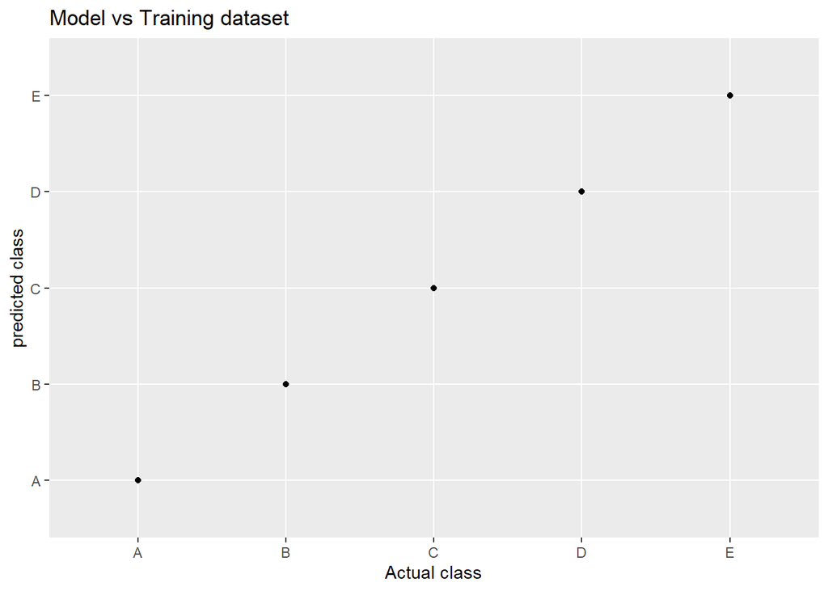

```r
qplot(as.factor(pmltrain2$classe),predtrain,xlab="Actual class",ylab="predicted class",main="Model vs Training dataset")
```

2. Now the model is tested on validation dataset to see the out-of-sample error.

```r
predval<-predict(modpml,newdata = pmlval1)
confusionMatrix(predval,as.factor(pmlval1$classe))
```

```
## Confusion Matrix and Statistics
##
##           Reference
## Prediction    A    B    C    D    E
##          A 1395    1    0    0    0
##          B    0  947    1    0    0
##          C    0    1  854    0    0
##          D    0    0    0  804    0
##          E    0    0    0    0  901
##
## Overall Statistics
##
##                Accuracy : 0.9994
##                  95% CI : (0.9982, 0.9999)
##     No Information Rate : 0.2845
##     P-Value [Acc > NIR] : < 2.2e-16
##
##                   Kappa : 0.9992
##
##  Mcnemar's Test P-Value : NA
##
## Statistics by Class:
##
##                      Class: A Class: B Class: C Class: D Class: E
## Sensitivity            1.0000   0.9979   0.9988   1.0000   1.0000
## Specificity            0.9997   0.9997   0.9998   1.0000   1.0000
## Pos Pred Value         0.9993   0.9989   0.9988   1.0000   1.0000
## Neg Pred Value         1.0000   0.9995   0.9998   1.0000   1.0000
## Prevalence             0.2845   0.1935   0.1743   0.1639   0.1837
## Detection Rate         0.2845   0.1931   0.1741   0.1639   0.1837
## Detection Prevalence   0.2847   0.1933   0.1743   0.1639   0.1837
## Balanced Accuracy      0.9999   0.9988   0.9993   1.0000   1.0000
```

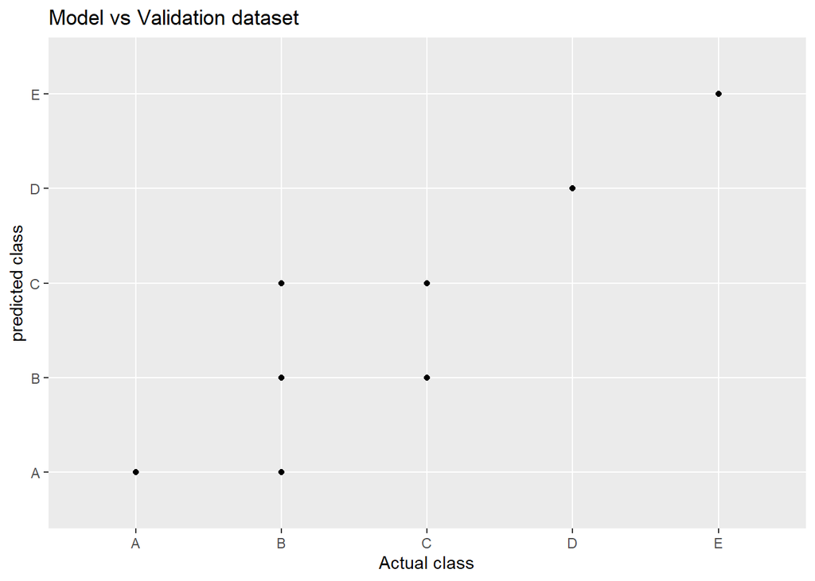

```r
qplot(as.factor(pmlval1$classe),predval,xlab="Actual class",ylab="predicted class",main="Model vs Validation dataset")
```

### Prediction:

Our model has high accuracy it can be now used for prediction on the testing dataset.

```r
predtest<-predict(modpml,newdata=pmltest1)
```

Following plots show the overall distribution of predicted classes and predicted classes for each user.

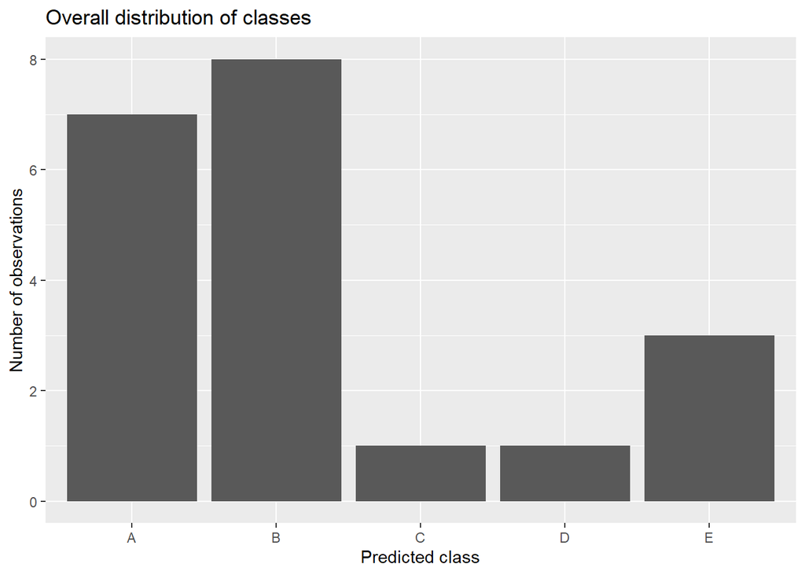

```r
pmltest1$user_name<-pmltest[,2]
qplot(predtest,main="Overall distribution of classes",xlab="Predicted class", ylab="Number of observations")
```

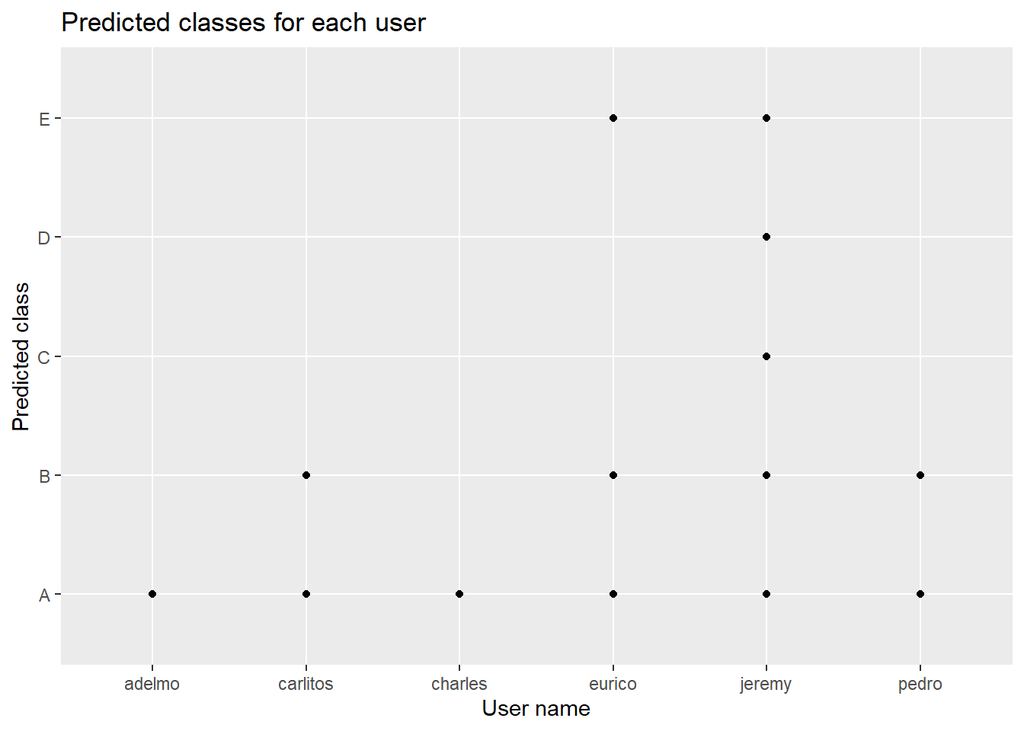

```r
qplot(pmltest1$user_name,predtest,main="Predicted classes for each user",xlab="User name",ylab="Predicted class")
```